# Talent Management Analysis

Allison Roderick

August 12, 2019

```r
# Load required libraries
library(ggplot2)
library(dplyr)
library(tidyr)
library(e1071)
library(stringr)
library(ggpubr)
library(knitr)
library(caret)
library(GGally)
library(olsrr)
# library(kableExtra)
# library(lemon)
# knit_print.data.frame = lemon_print

# Read in data
path1="C:/Users/Allison/Desktop/SMU/19U/Doing Data Science/MSDS-6306-Doing-Data-Science/UNIT 14/CaseStudy2-data.csv"
df=read.csv(path1)

# Remove variables that are monotonic
df = subset(df, select=-c(EmployeeCount,StandardHours,Over18))

# Create a new variable that gets the last word of JobRole
df = df %>% mutate(Role = word(JobRole,-1))
df$Role = as.factor(df$Role)

# Create a new variable that is an indicator for Attrition
df = df %>% mutate(Attrit = ifelse(Attrition == 'Yes',1,0))

# Create new dataframe that only has numeric variables (along with ID and Attrition)
nums = unlist(lapply(df, is.numeric))
nums[[3]]=TRUE
df_num=df[,nums]

# Create new dataframe that only has factor variables (along with ID and Attrition)
nums = unlist(lapply(df, is.numeric))
nums[[1]]=FALSE
df_factor=df[,!nums]
```

# Introduction

**Who You Are** Frito-Lay has over 10,000 employees across multiple departments and at multiple levels. The company is looking to utilize data science to understand and reduce voluntary employee attrition.

**Who We Are** For over a decade and for dozens of customers, DDSAnalytics has specialized in using data science to provide talent management solutions.

**What We Offer** In this report, we will identify the top factors contributing to attrition, the top factors that predict monthly income, and we will provide predicted values for both on a subset of employees.

Please see a video presentation of this analysis at https://youtu.be/bP_vMaD4bpg.

# Attrition

## Exploratory Data Analysis

We were given a dataset of 870 employees with both numeric variables (e.g., Monthly Income, Age, etc.) and categorical variables (e.g. Over Time, Job Role, etc.). To begin our exploratory data analysis, we split up the numeric and categorical (“factor”) variables.

### Numeric Variables

#### A statistical approach

In this exploratory stage, our goal is to understand what variables are highly correlated to attrition. To accomplish this with numeric variables, we performed Welch’s Two Sample T Tests on each of the variables. These tests answer the question: Is the mean of the variable for employees who left the company significantly different than those who stayed at the company?

```r
# Split numeric dataset into Attritions and no Attritions
AttritionYes = df_num %>% filter(Attrition=='Yes')
AttritionNo = df_num %>% filter(Attrition=='No')

# Iteratively perform t tests
my_cols = vector()
p=vector()
for (i in 4 : 26) {
  t=t.test(AttritionNo[,i],AttritionYes[,i],
           alternative = "two.sided", var.equal = FALSE)
 p[i-3] = t$p.value
 my_cols[i-3] = colnames(AttritionNo)[i]
}
# Perform t test on age which is in column 2
t=t.test(AttritionNo$Age,AttritionYes$Age,alternative = "two.sided", var.equal = FALSE)
p[27-3]=t$p.value
my_cols[27-3]="Age"

# Create dataframe of variables and associated p-values
my_num = as.data.frame(cbind(my_cols,p))
options(scipen=999)
my_num$p.num = as.numeric(as.character(my_num$p))
my_num$p.num = round(my_num$p.num,10)
my_num = my_num[order(my_num$p.num),]
my_num1=subset(my_num, select=c(my_cols, p.num))
kable(my_num1,col.names = c("Variable","P-Value"), row.names =FALSE)
```

| Variable | P-Value |
| --- | --- |
| MonthlyIncome | 0.0000002 |
| JobLevel | 0.0000004 |
| TotalWorkingYears | 0.0000007 |
| YearsInCurrentRole | 0.0000015 |
| JobInvolvement | 0.0000020 |
| YearsWithCurrManager | 0.0000051 |
| StockOptionLevel | 0.0000386 |
| Age | 0.0000505 |
| YearsAtCompany | 0.0002563 |
| JobSatisfaction | 0.0014973 |
| DistanceFromHome | 0.0164052 |
| WorkLifeBalance | 0.0190089 |
| EnvironmentSatisfaction | 0.0339727 |
| TrainingTimesLastYear | 0.0594832 |
| NumCompaniesWorked | 0.0978823 |
| Education | 0.1421319 |
| MonthlyRate | 0.1980950 |
| RelationshipSatisfaction | 0.2639669 |
| HourlyRate | 0.2744798 |
| DailyRate | 0.3188749 |
| EmployeeNumber | 0.4978776 |
| PerformanceRating | 0.6610278 |
| PercentSalaryHike | 0.6692297 |
| YearsSinceLastPromotion | 0.8983165 |

From the table above, we can see that there are 15 numeric variables that have different means depending on whether the employee attritted or not (15 variables with p-value less than the alpha level of 0.1). The other 9 variables have no evidence that the mean values are different depending on attrition. Thus, the initial numeric variables we are considering in our Attrition model are:

- MonthlyIncome
- JobLevel
- TotalWorkingYears
- YearsInCurrentRole
- JobInvolvement
- YearsWithCurrManager
- StockOptionLevel
- Age
- YearsAtCompany
- JobSatisfaction
- DistanceFromHome
- WorkLifeBalance
- EnvironmentSatisfaction
- TrainingTimesLastYear
- NumCompaniesWorked

#### A visual approach

We can visually compare the variables by whether the employee attritted or not by looking at boxplots of the data. Below can see visually that

- Some variables, like MonthlyIncome and TotalWorkingYears, have significantly different means depending on Attrition
- Some variables, like Education and YearsSinceLastPromotion, have no significant difference in means depending on Attrition

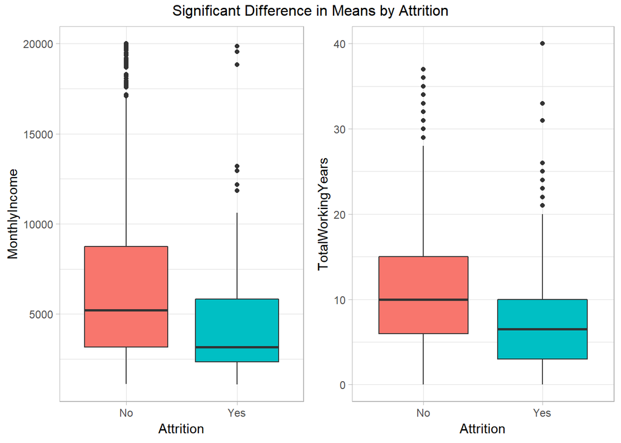

```r
# Create boxplots for two variables wih strong correlation to Attrition, two without
p1=ggplot(df, aes(x = Attrition, y = MonthlyIncome, fill = Attrition)) +
  geom_boxplot() +
  theme_light() + theme(legend.position="none")
p2=ggplot(df, aes(x = Attrition, y = TotalWorkingYears, fill = Attrition)) +
  geom_boxplot() +
  theme_light() + theme(legend.position="none")
p3=ggplot(df, aes(x = Attrition, y = Education, fill = Attrition)) +
  geom_boxplot() +
  theme_light() + theme(legend.position="none")
p4=ggplot(df, aes(x = Attrition, y = YearsSinceLastPromotion , fill = Attrition)) +
  geom_boxplot() +
  theme_light() + theme(legend.position="none")
fig1=ggarrange(p1,p2,ncol=2,nrow=1)
annotate_figure(fig1,top=text_grob("Significant Difference in Means by Attrition"))
```

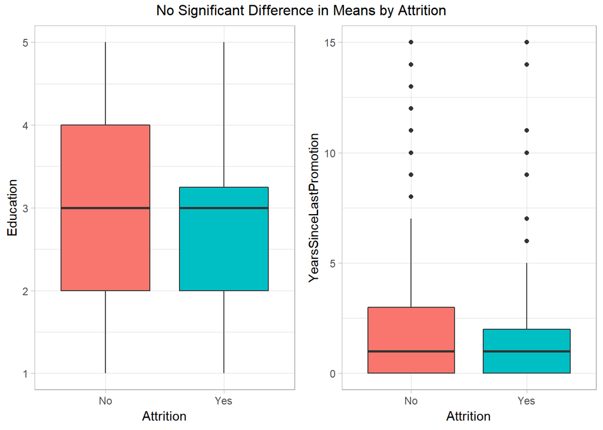

```r
fig2=ggarrange(p3,p4,ncol=2,nrow=1)
annotate_figure(fig2,top=text_grob("No Significant Difference in Means by Attrition"))
```

### Categorical Variables

#### A statistical approach

Next, we look at the categorical variables. Below is an example table comparing one of our categorical variables, BusinessTravel, to Attrition.

```r
table = table(df_factor[,3], df_factor$Attrition)
kable(table, caption=colnames(df_factor)[3])
```

BusinessTravel

|  | No | Yes |
| --- | --- | --- |
| Non-Travel | 83 | 11 |
| Travel_Frequently | 123 | 35 |
| Travel_Rarely | 524 | 94 |

We can see that, for both “Yes” and “No” Attrition employees, most travel rarely, while some travel frequently, and the smallest group is non-travel. However, we want to be able to show statistically whether Attrition and BusinessTravel are related. Hence, we use a chi-square test for independence on all of the categorical variables, testing to see if they are related to Attrition.

```r
# Iteratively perform chi squared test
fact_cols = vector()
p.chisq=vector()
for (i in 3:10) {
  table = table(df_factor[,i], df_factor$Attrition)
  chi = chisq.test(table)
  p.chisq[i-2] = chi$p.value
  fact_cols[i-2] = colnames(df_factor)[i]
}
# Create dataframe of variables and associated p-values
my_fact = as.data.frame(cbind(fact_cols,p.chisq))
options(scipen=999)
my_fact$p.num = as.numeric(as.character(my_fact$p.chisq))
my_fact$p.num = round(my_fact$p.num,10)
my_fact = subset(my_fact,select=-p.chisq)
my_fact = my_fact[order(my_fact$p.num),]
my_fact1=subset(my_fact, select=c(fact_cols, p.num))
kable(my_fact1,col.names = c("Variable","P-Value"), row.names =FALSE)
```

| Variable | P-Value |
| --- | --- |
| OverTime | 0.0000000 |
| JobRole | 0.0000000 |
| MaritalStatus | 0.0000000 |
| Role | 0.0000125 |
| Department | 0.0094238 |
| BusinessTravel | 0.0499254 |
| EducationField | 0.2682198 |
| Gender | 0.5151297 |

As shown in the table above, there are 6 categorical variables that show evidence of association with Attrition (6 variables with p-value less than alpha=0.1). The other 2 variables have no evidence of association with Attrition.

**Note** The variable Role was created for this analysis in efforts to reduce the number of distinct values that JobRole can take on. As we see above, JobRole is a highly associated variable with Attrition. However, as we see in the table below, some combinations of JobRole and Attrition occur very few times (e.g., only one Research Director has attritted). Thus, when we train our model, we will run into issues of not having enough information to make predictions off of such combinations.

```r
table = table(df_factor$JobRole, df_factor$Attrition)
table2 = table(df_factor$Role, df_factor$Attrition)
table %>% kable(caption="JobRole")
```

JobRole

|  | No | Yes |
| --- | --- | --- |
| Healthcare Representative | 68 | 8 |
| Human Resources | 21 | 6 |
| Laboratory Technician | 123 | 30 |
| Manager | 47 | 4 |
| Manufacturing Director | 85 | 2 |
| Research Director | 50 | 1 |
| Research Scientist | 140 | 32 |
| Sales Executive | 167 | 33 |
| Sales Representative | 29 | 24 |

```r
table2 %>% kable(caption="Role")
```

Role

|  | No | Yes |
| --- | --- | --- |
| Director | 135 | 3 |
| Executive | 167 | 33 |
| Manager | 47 | 4 |
| Representative | 97 | 32 |
| Resources | 21 | 6 |
| Scientist | 140 | 32 |
| Technician | 123 | 30 |

However, when we try to combine some of the groups of JobRole by taking only the last word of JobRole to create Role, we see fewer such issues.

Thus, the categorical variables we are considering in our Attrition model are:

- OverTime
- MaritalStatus
- Role
- Department
- BusinessTravel

#### A visual approach

We can visualize the difference between association with Attrition and no association with Attrition as shown below.

[figure not shown]

```r
# barplot for Role - association with Attrition
agg = count(df_factor, Role, Attrition) %>%
  mutate(Percentage = n / sum(n))
agg_ord = mutate(agg, Role = reorder(Role,-Percentage,sum))
v1=ggplot(agg_ord) +
  geom_col(aes(x = Role, y = Percentage, fill = Attrition)) +
  ggtitle("Attrition Signficantly Lower Proportion for Directors, Executives") +
  theme(plot.title = element_text(hjust = 0.5))

# barplot for EducationField - no association with Attrition
agg = count(df_factor, EducationField, Attrition) %>%
  mutate(Percentage = n / sum(n))
agg_ord = mutate(agg, EducationField = reorder(EducationField,-Percentage,sum))
v2=ggplot(agg_ord) +
  geom_col(aes(x = EducationField, y = Percentage, fill = Attrition)) +
  ggtitle("No Association Between EducationField and Attrition")  +
  theme(plot.title = element_text(hjust = 0.5))

fig1=ggarrange(v1,v2,ncol=1,nrow=2)
fig1
```

In the first plot above, we see that “Yes” attritted employees do not follow the overall distribution of employees by Role.

- Directors have a smaller share of the employees that attritted than they do of employees overall.
- Representatives have a larger share of employees that attrtted than they do of employees overall.

In the second plot, we see that the “Yes”attritted employees do follow the general distributions of employees by EducationField. These graphs reiterate the fact that Role is signficantly associated with Attrition, while EducationField is not.

## Modeling Attrition - Naive Bayes

For our model, we chose to use a Naive Bayes model. Naive Bayes is a relatively simple model that is good at predicting “Yes”/“No” binary data, as we have with Attrition.

One potential concern with Naive Bayes is that the model assumes all of the predictors are independent. We will see later, when exploring MonthlyIncome, that many of the variables that are signficantly correlated with Attrition are also collinear with each other (e.g., YearsInCurrentRole and YearsAtCompany). For now, we will move forward with this model.

In order to train our model, we are going to use the sample employees provided to us and train/test on a 50/50 split. Before partitioning the data, we find the unique combinations of categorical variables and how many employees have those combinations. If there is a combination with only 1 employee, we remove that employee from the train/test datasets. This initial step removes 59 employees from the sample.

```r
# Count rows in sample
nrow(df)
```

```
## [1] 870
```

```r
# Identify combinations that only occur once
mydf = df %>%
  mutate(all = paste(Attrition,OverTime,Role,
                     MaritalStatus,Department,BusinessTravel)) %>%
  group_by(all) %>%
  summarise(total=n()) %>%
  filter(total>=2)

# Remove combinations that only occur once
df0 = df[paste(df$Attrition,df$OverTime,df$Role,df$MaritalStatus,df$Department,df$BusinessTravel) %in% mydf$all,]

# Now count rows in sample
nrow(df0)
```

```
## [1] 811
```

Now that we have narrowed our data down, we can partition the data and train our model.

```r
# Narrow down sample to variables of interest
df1 = subset(df0, select=c(Attrition,MonthlyIncome,JobLevel,TotalWorkingYears,YearsInCurrentRole,
                           JobInvolvement,YearsWithCurrManager,JobSatisfaction,StockOptionLevel,Age,
                           DistanceFromHome,WorkLifeBalance, EnvironmentSatisfaction,
                           OverTime,Role,NumCompaniesWorked,YearsAtCompany,TrainingTimesLastYear,
                           MaritalStatus,Department,BusinessTravel))

# Randomize order of rows
set.seed(201)
df1_idx = sample(1:nrow(df1), replace = FALSE)
df1 = df1[df1_idx, ]

# Partition into 50/50 train/test split
indxTrain = createDataPartition(y = df1$Attrition,p = 0.5,list = FALSE)
training = df1[indxTrain,]
testing = df1[-indxTrain,]

# #Check dimensions of the split
# prop.table(table(df1$Attrition)) * 100
# prop.table(table(training$Attrition)) * 100
# prop.table(table(testing$Attrition)) * 100
# # Check 50/50 split
# nrow(training)/nrow(df1)

# Separate predictor variables and Attrition
x = training[,-1]
y = training[,1]

# Train for specificity
trainMethod = trainControl( method = "repeatedcv", number = 25, repeats = 5, summaryFunction = twoClassSummary, classProbs = TRUE)
set.seed(201)
model = train(x,y,method = "nb", metric = "Spec", trControl = trainMethod)
# model

# Predict testing set
Predict = predict(model,newdata = testing[,-1] )

# Model performance
confusionMatrix(Predict, testing$Attrition )
```

```
## Confusion Matrix and Statistics
##
##           Reference
## Prediction  No Yes
##        No  310  19
##        Yes  39  37
##
##                Accuracy : 0.8568
##                  95% CI : (0.8188, 0.8894)
##     No Information Rate : 0.8617
##     P-Value [Acc > NIR] : 0.6461
##
##                   Kappa : 0.4774
##
##  Mcnemar's Test P-Value : 0.0126
##
##             Sensitivity : 0.8883
##             Specificity : 0.6607
##          Pos Pred Value : 0.9422
##          Neg Pred Value : 0.4868
##              Prevalence : 0.8617
##          Detection Rate : 0.7654
##    Detection Prevalence : 0.8123
##       Balanced Accuracy : 0.7745
##
##        'Positive' Class : No
##
```

As the results of our model show above, our model has a Sensitivity rate of 89% and a Specificity rate of 66%. We expected our model to have a higher Sensitvity rate than Specificity rate because, since our base sample of employees had far fewer attritions (“Y”) than no attrition (“N”), we would expect our rate of correctly labeling “N” as “N” (Sensitivity rate) to be higher than correctly labeling “Y” as “Y” (Specificity rate).

As we see below, MaritalStatus, StockOptionLevel, and YearsInCurrentRole are the top 3 contributers to the model for predicting Attrition.

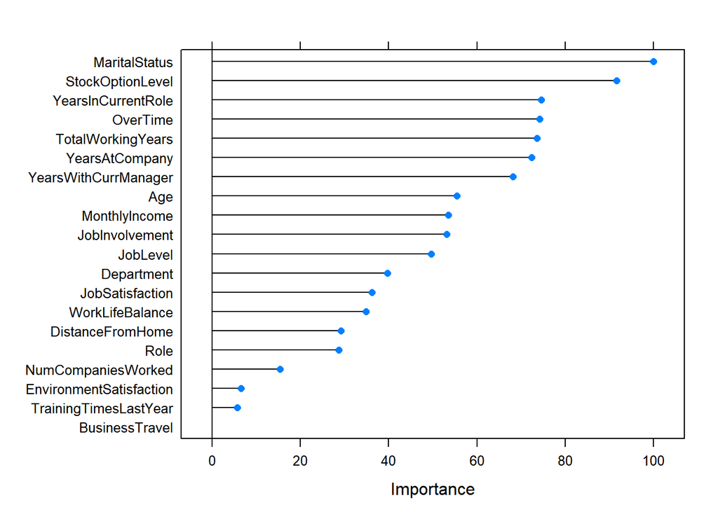

```r
# Plot variable performance
plot(varImp(model))
```

# Monthly Income

## Exploratory Data Analysis

Our next task was to build a linear regression model for predicting Monthly Income. In order to accomplish that, not only did we look at what variables were highly correlated with Monthly Income, but also what variables were correlated with each other. Our goal was to build a model that not only had as few predictors as necessary but also was without any collinear variables.

### Numeric Variables

First, we check for variables that are linearly related to Monthly Income.

```r
# Function for extracting p-value from linear model
lmp = function (modelobject) {
  if (class(modelobject) != "lm") stop("Not an object of class 'lm' ")
  f = summary(modelobject)$fstatistic
  p = pf(f[1],f[2],f[3],lower.tail=F)
  attributes(p) <- NULL
  return(p)
}

# Iteratively calculate p-value and r^2 from linear models, comparing numeric variables to MonthlyIncome
lms = list()
my_cols = vector()
rsqr = vector()
p=vector()
for (i in 4 : 26) {
  my_lm = lm(df_num$MonthlyIncome ~ df_num[,i])
  lms[[i]] = summary(my_lm)
  my_cols[i-3] = colnames(df_num)[i]
  rsqr[i-3] = summary(my_lm)$r.squared
  p[i-3]=lmp(my_lm)
}
my_lm = lm(df_num$MonthlyIncome ~ df_num[,2])
lms[[2]] = summary(my_lm)
my_cols[27-3] = colnames(df_num)[2]
rsqr[27-3] = summary(my_lm)$r.squared
p[27-3]=lmp(my_lm)

lm_fits = as.data.frame(cbind(my_cols,rsqr,p))
lm_fits$p.num = as.numeric(as.character(lm_fits$p))
lm_fits = subset(lm_fits, select=-p)
lm_fits$p.num = round(lm_fits$p.num,10)
lm_fits = lm_fits %>% arrange(p.num)
lm_fits1=subset(lm_fits, select=c(my_cols, rsqr, p.num)) %>% dplyr::filter(my_cols != "MonthlyIncome")
kable(lm_fits1,col.names = c("Variable","R-Squared","P-Value"), row.names =FALSE)
```

| Variable | R-Squared | P-Value |
| --- | --- | --- |
| JobLevel | 0.905618782515038 | 0.0000000 |
| TotalWorkingYears | 0.606079696981585 | 0.0000000 |
| YearsAtCompany | 0.241453288232577 | 0.0000000 |
| YearsInCurrentRole | 0.130928562340905 | 0.0000000 |
| YearsSinceLastPromotion | 0.099800123808841 | 0.0000000 |
| YearsWithCurrManager | 0.107904006571101 | 0.0000000 |
| Age | 0.234535158438085 | 0.0000000 |
| NumCompaniesWorked | 0.0243030385039351 | 0.0000038 |
| Education | 0.0161623913589456 | 0.0001701 |
| MonthlyRate | 0.00417239346658138 | 0.0568449 |
| PercentSalaryHike | 0.00290153934606051 | 0.1123575 |
| JobSatisfaction | 0.00282476619133436 | 0.1172293 |
| PerformanceRating | 0.00186028283714284 | 0.2037486 |
| TrainingTimesLastYear | 0.00152213645240748 | 0.2503303 |
| EmployeeNumber | 0.00116984848069776 | 0.3136036 |
| WorkLifeBalance | 0.000432843394413688 | 0.5399821 |
| StockOptionLevel | 0.000356783815008709 | 0.5779471 |
| EnvironmentSatisfaction | 0.000284847939317069 | 0.6190955 |
| DistanceFromHome | 0.0000444509502607503 | 0.8443188 |
| RelationshipSatisfaction | 0.0000150907212299601 | 0.9089071 |
| HourlyRate | 0.00000571760163024226 | 0.9438534 |
| JobInvolvement | 0.00000020014814097907 | 0.9894867 |
| DailyRate | 0.00000000772700630218248 | 0.9979342 |

Next, we must ensure that we do not include any collinear variables in our linear regression model. When we look at just the variables with “Years” in the name, we see that they are all collinear with each other.

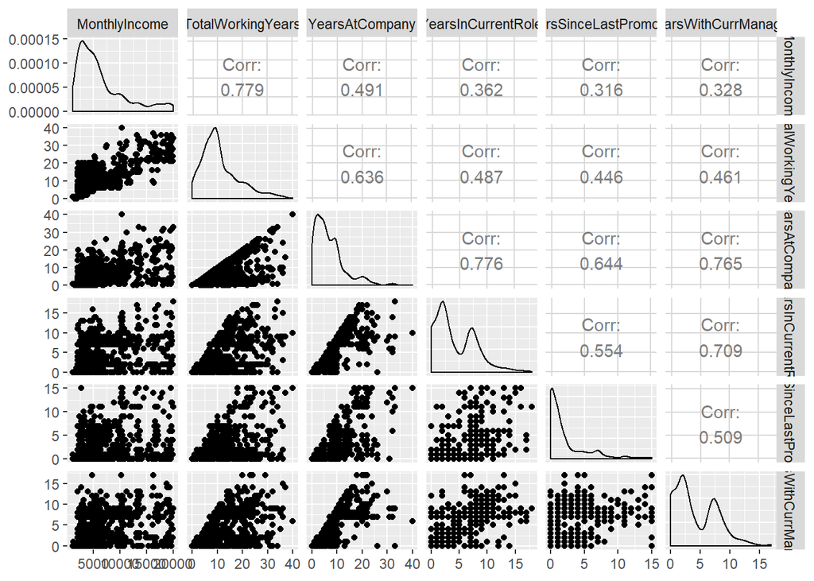

```r
ggpairs(subset(df_num, select=c(MonthlyIncome,TotalWorkingYears,YearsAtCompany,YearsInCurrentRole,
                                YearsSinceLastPromotion,YearsWithCurrManager)))
```

Since TotalWorkingYears has the lowest p-value of those, we will exclude the other “Year” variables and compare TotalWorkingYears it to all of the other numeric variables.

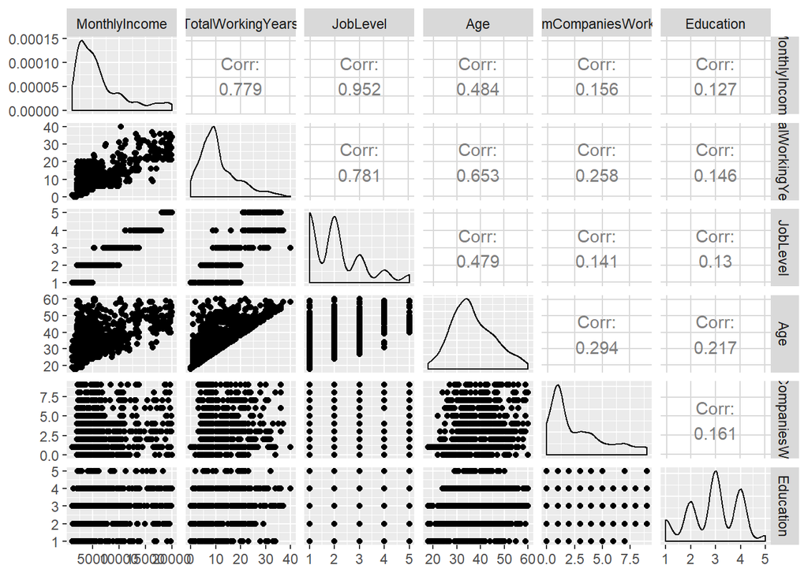

```r
ggpairs(subset(df_num, select=c(MonthlyIncome,TotalWorkingYears,JobLevel,Age,NumCompaniesWorked,Education)))
```

Because both TotalWorkingYears and Age are corelated with JobLevel and JobLevel has the lowest p-value, we will remove TotalWorkingYears and Age from inclusion in the model. The other variables, NumCompaniesWorked and Education, do not appear to be collinear. Thus, the only numeric variables that will be included for consideration in the model are:

- JobLevel
- NumCompaniesWorked
- Education

### Categorical Variables

Next, we need to check if any categorical variables are associated with Monthly Income. First, we notice that since Monthly Income is not normally distributed, we can use a Kruskal-Wallis Test to determine whether Monthly Income is distributed differently depending on the category of the variables.

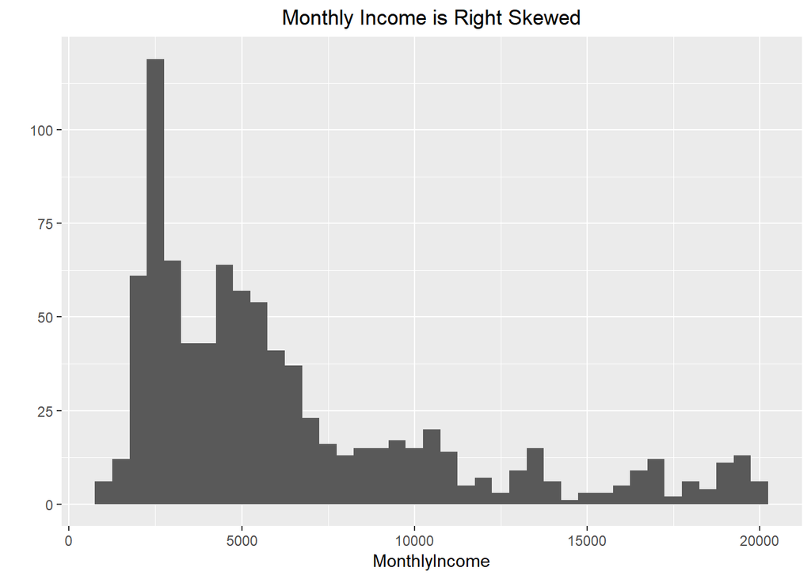

```r
# Display distributino of MonthlyIncome
ggplot(data=df, aes(x=MonthlyIncome)) +
  geom_histogram(binwidth=500) +
  ylab("") +
  ggtitle("Monthly Income is Right Skewed") +
  theme(plot.title = element_text(hjust = 0.5))
```

```r
# Get p-values from Kruskal-Wallis tests
kw_fits = data.frame("BusinessTravel",
                     kruskal.test(MonthlyIncome ~ BusinessTravel, data = df)[[3]])
names(kw_fits) = c("Variable","p")
kw_fits$Variable = as.character(kw_fits$Variable)

kw_fits[nrow(kw_fits)+1,]=c("Department",
                            kruskal.test(MonthlyIncome ~ Department, data = df)[[3]])
kw_fits[nrow(kw_fits)+1,]=c("EducationField",
                            kruskal.test(MonthlyIncome ~ EducationField, data = df)[[3]])
kw_fits[nrow(kw_fits)+1,]=c("Gender",
                            kruskal.test(MonthlyIncome ~ Gender, data = df)[[3]])
kw_fits[nrow(kw_fits)+1,]=c("Role",
                            kruskal.test(MonthlyIncome ~ Role, data = df)[[3]])
kw_fits[nrow(kw_fits)+1,]=c("MaritalStatus",
                            kruskal.test(MonthlyIncome ~ MaritalStatus, data = df)[[3]])
kw_fits[nrow(kw_fits)+1,]=c("OverTime",
                            kruskal.test(MonthlyIncome ~ OverTime, data = df)[[3]])
# str(kw_fits)
# kw_fits

kw_fits$p.num = as.numeric(as.character(kw_fits$p))
kw_fits = subset(kw_fits, select=-p)
kw_fits$p.num = round(kw_fits$p.num,10)
kw_fits = kw_fits[order(kw_fits$p.num),]
kw_fits1=subset(kw_fits, select=c(Variable, p.num))
kable(kw_fits1,col.names = c("Variable","P-Value"), row.names =FALSE)
```

| Variable | P-Value |
| --- | --- |
| Role | 0.0000000 |
| Department | 0.0000028 |
| EducationField | 0.0082740 |
| MaritalStatus | 0.0092883 |
| Gender | 0.0462139 |
| BusinessTravel | 0.3260119 |
| OverTime | 0.6160406 |

To visualize that Role, Department, EducationField, MaritalStatus, and Gender have different distributions based on their categories, we see the density plots below.

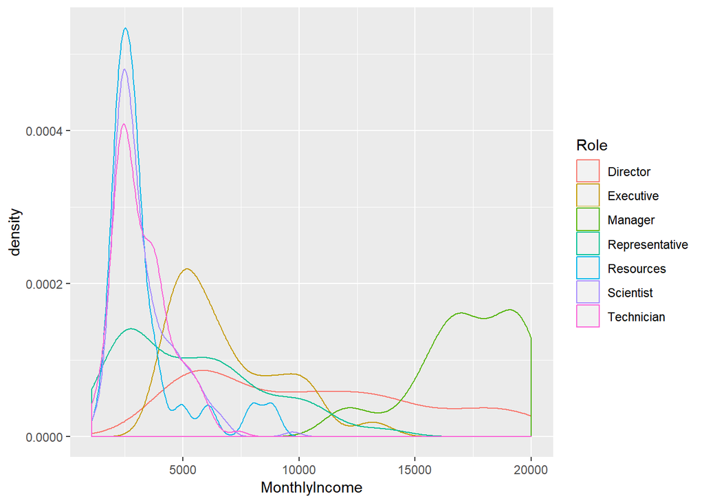

```r
d1=ggplot(data = df, aes(x = MonthlyIncome, color = BusinessTravel)) + geom_density()
d2=ggplot(data = df, aes(x = MonthlyIncome, color = Department)) + geom_density()
d3=ggplot(data = df, aes(x = MonthlyIncome, color = EducationField)) + geom_density()
d4=ggplot(data = df, aes(x = MonthlyIncome, color = Gender)) + geom_density()
d5=ggplot(data = df, aes(x = MonthlyIncome, color = Role)) + geom_density()
d6=ggplot(data = df, aes(x = MonthlyIncome, color = MaritalStatus)) + geom_density()
d7=ggplot(data = df, aes(x = MonthlyIncome, color = OverTime)) + geom_density()
#fig1=ggarrange(d5,d2,d3,d6,d4, ncol=2,nrow=3)
#fig1
d5
```

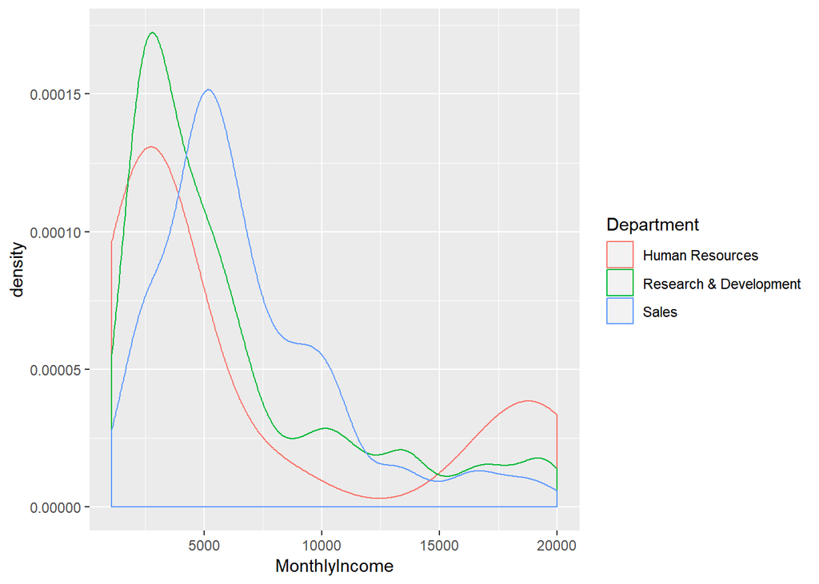

```r
d2
```

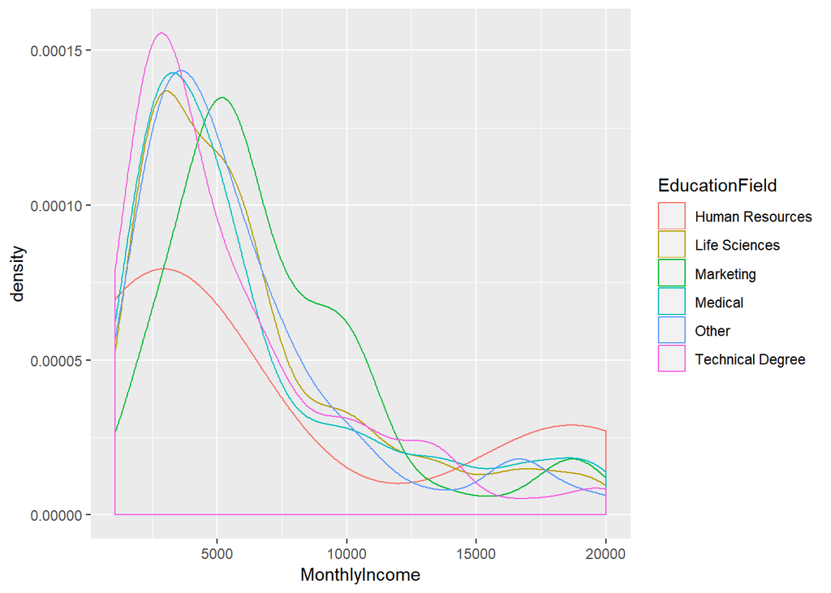

```r
d3
```

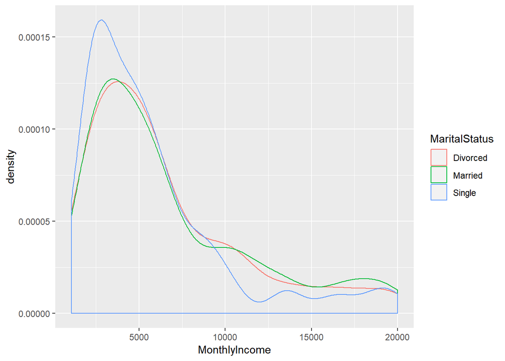

```r
d6
```

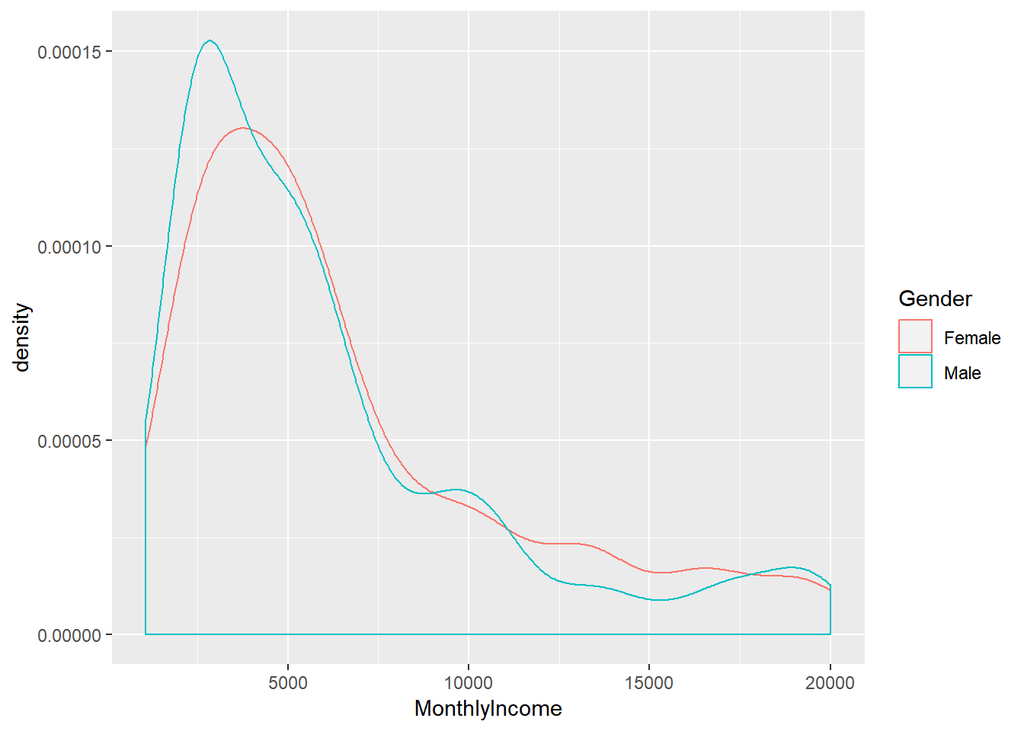

```r
d4
```

Thus, the only characters variables that will be included for consideration in the model are:

- Role
- Department
- EducationField
- MaritalStatus
- Gender

## Modeling Monthly Income - Multiple Linear Regression

We now proceed to create a linear regression to model Monthly Income. We will use a stepwise selection method for determining which of the 8 variables we will include in our final model.

```r
set.seed(201)
df_step = subset(df, select=c(MonthlyIncome,JobLevel,NumCompaniesWorked,Education,Role,
                                Department,MaritalStatus,EducationField,Gender))

step_model = lm(MonthlyIncome ~ ., data=df_step)
ols_step_forward_aic(step_model, details=TRUE)
```

```
## Forward Selection Method
## ------------------------
##
## Candidate Terms:
##
## 1 . JobLevel
## 2 . NumCompaniesWorked
## 3 . Education
## 4 . Role
## 5 . Department
## 6 . MaritalStatus
## 7 . EducationField
## 8 . Gender
##
##  Step 0: AIC = 17145.91
##  MonthlyIncome ~ 1
##
## -------------------------------------------------------------------------------------------------
## Variable              DF       AIC           Sum Sq               RSS          R-Sq     Adj. R-Sq
## -------------------------------------------------------------------------------------------------
## JobLevel               1    15094.353    16635876872.790     1733747514.405    0.906        0.906
## Role                   1    16238.020    11988465120.030     6381159267.165    0.653        0.650
## NumCompaniesWorked     1    17126.508      446437688.785    17923186698.411    0.024        0.023
## Education              1    17133.737      296897058.463    18072727328.733    0.016        0.015
## MaritalStatus          1    17140.743      192611181.730    18177013205.465    0.010        0.008
## EducationField         1    17150.372      116612631.995    18253011755.200    0.006        0.001
## Department             1    17146.345       75182685.855    18294441701.341    0.004        0.002
## Gender                 1    17145.262       55885989.779    18313738397.416    0.003        0.002
## -------------------------------------------------------------------------------------------------
##
##
## - JobLevel
##
##
##  Step 1 : AIC = 15094.35
##  MonthlyIncome ~ JobLevel
##
## ----------------------------------------------------------------------------------------------
## Variable              DF       AIC          Sum Sq             RSS          R-Sq     Adj. R-Sq
## ----------------------------------------------------------------------------------------------
```

[output cut: 92 more lines]

```
##                                           Parameter Estimates
## --------------------------------------------------------------------------------------------------------
##              model         Beta    Std. Error    Std. Beta      t        Sig         lower        upper
## --------------------------------------------------------------------------------------------------------
##        (Intercept)     -319.556       227.653                 -1.404    0.161     -766.377      127.264
##           JobLevel     3577.325        65.059        0.848    54.986    0.000     3449.632     3705.019
##      RoleExecutive    -1334.412       146.697       -0.122    -9.096    0.000    -1622.338    -1046.486
##        RoleManager     1810.176       225.377        0.093     8.032    0.000     1367.823     2252.529
## RoleRepresentative    -1111.366       170.963       -0.086    -6.501    0.000    -1446.920     -775.812
##      RoleResources     -946.092       290.468       -0.036    -3.257    0.001    -1516.201     -375.982
##      RoleScientist     -860.380       186.247       -0.075    -4.620    0.000    -1225.931     -494.829
##     RoleTechnician    -1189.001       186.182       -0.099    -6.386    0.000    -1554.424     -823.577
## NumCompaniesWorked       37.983        17.341        0.021     2.190    0.029        3.948       72.017
##         GenderMale      144.599        88.070        0.015     1.642    0.101      -28.259      317.457
## --------------------------------------------------------------------------------------------------------
```

```
##
##                                      Selection Summary
## --------------------------------------------------------------------------------------------
## Variable                 AIC           Sum Sq              RSS           R-Sq      Adj. R-Sq
## --------------------------------------------------------------------------------------------
## JobLevel              15094.353    16635876872.790    1733747514.405    0.90562      0.90551
## Role                  14917.586    16974043481.505    1395580905.691    0.92403      0.92341
## NumCompaniesWorked    14914.801    16981696808.029    1387927579.166    0.92444      0.92374
## Gender                14914.079    16986033693.716    1383590693.480    0.92468      0.92389
## --------------------------------------------------------------------------------------------
```

```r
final_model = lm(MonthlyIncome ~ JobLevel + Role + NumCompaniesWorked + Gender, data=df)
summary(final_model)
```

```
##
## Call:
## lm(formula = MonthlyIncome ~ JobLevel + Role + NumCompaniesWorked +
##     Gender, data = df)
##
## Residuals:
##     Min      1Q  Median      3Q     Max
## -4328.9  -748.7   -20.3   714.2  4278.7
##
## Coefficients:
##                    Estimate Std. Error t value             Pr(>|t|)
## (Intercept)         -319.56     227.65  -1.404              0.16077
## JobLevel            3577.33      65.06  54.986 < 0.0000000000000002 ***
## RoleExecutive      -1334.41     146.70  -9.096 < 0.0000000000000002 ***
## RoleManager         1810.18     225.38   8.032  0.00000000000000315 ***
## RoleRepresentative -1111.37     170.96  -6.501  0.00000000013542038 ***
## RoleResources       -946.09     290.47  -3.257              0.00117 **
## RoleScientist       -860.38     186.25  -4.620  0.00000443326743683 ***
## RoleTechnician     -1189.00     186.18  -6.386  0.00000000027798070 ***
## NumCompaniesWorked    37.98      17.34   2.190              0.02876 *
## GenderMale           144.60      88.07   1.642              0.10099
## ---
## Signif. codes:  0 '***' 0.001 '**' 0.01 '*' 0.05 '.' 0.1 ' ' 1
##
## Residual standard error: 1268 on 860 degrees of freedom
## Multiple R-squared:  0.9247, Adjusted R-squared:  0.9239
## F-statistic:  1173 on 9 and 860 DF,  p-value: < 0.00000000000000022
```

Our final resulting model, as shown above, includes JobLevel, Role, NumCompaniesWorked, and Gender (in order of signficance, based on p-value). These predictors explain approximately 92.39% of the variance in Monthly Income. The RMSE is $1,268.

# Final Thoughts

In conclusion, there are multiple factors that might contribute to voluntary employee attrition. Some are uncontrollable, such as Marital Status, some are only measurable, such as Years in Current Role, but some can be altered by Frito-Lay to reduce voluntary attrition, such as Stock Option Level, Over Time, Monthly Income, as well as others.

For the next steps, DDSAnalytics recommends the possibility of adjusting fields such as Stock Option Level and Over Time, particularly focusing on Roles that have a higher rate of Attrition, such as Representatives.

Additionally, DDSAnalytics has provided Frito-Lay predictions based on the Attrition and Monthly Income models on the datasets provided for your consideration.

```r
# Predicting Attrition
path2="C:/Users/Allison/Desktop/SMU/19U/Doing Data Science/MSDS-6306-Doing-Data-Science/UNIT 14/CaseStudy2CompSet No Attrition.csv"
NoAttrition = read.csv(path2)

# Subset columns used in model
NoAttrition1 = subset(NoAttrition, select=c(ID,MonthlyIncome,JobLevel,TotalWorkingYears,YearsInCurrentRole,
                                           JobInvolvement,YearsWithCurrManager,JobSatisfaction,StockOptionLevel,Age,
                                           DistanceFromHome,WorkLifeBalance, EnvironmentSatisfaction,
                                           OverTime,JobRole,NumCompaniesWorked,YearsAtCompany,TrainingTimesLastYear,
                                           MaritalStatus,Department,BusinessTravel))
NoAttrition1 = NoAttrition1 %>% mutate(Role = word(JobRole,-1))
NoAttrition1$Role = as.factor(NoAttrition1$Role)

# Predict Attrition
PredAttrition = predict(model, newdata=NoAttrition1)
NoAttrition2 = cbind(NoAttrition1,PredAttrition)

# Sanity check - is the rate of Attrition for the predicted values similar to the training set?
nrow(NoAttrition2[which(NoAttrition2$PredAttrition=="Yes"),])/nrow(NoAttrition2)
```

```
## [1] 0.1666667
```

```r
nrow(df[which(df$Attrition=="Yes"),])/nrow(df)
```

```
## [1] 0.1609195
```

```r
# Sort by ID
NoAttrition2 = NoAttrition2 %>% arrange(ID) %>% select(ID,PredAttrition)

# Write Attrition predictions to csv
# write.csv(NoAttrition2,
#           file="C:/Users/Allison/Desktop/SMU/19U/Doing Data Science/Case2PredictionsRoderick Attrition.csv",
#           row.names=FALSE)

# Predicting MonthlyIncome
path3="C:/Users/Allison/Desktop/SMU/19U/Doing Data Science/MSDS-6306-Doing-Data-Science/UNIT 14/CaseStudy2CompSet No Salary.csv"
NoSalary = read.csv(path3)

# Subset columns used in model
NoSalary1 = subset(NoSalary, select=c(ID, JobLevel, JobRole, NumCompaniesWorked, Gender))
NoSalary1 = NoSalary1 %>% mutate(Role = word(JobRole,-1))
NoSalary1$Role = as.factor(NoSalary1$Role)

# Predict MonthlyIncome
PredMonthlyInc = predict(final_model, newdata=NoSalary1, type='response')

# Sanity check - is the mean of MonthlyIncome for the predicted values similar to the training set?
mean(PredMonthlyInc)
```

```
## [1] 6249.73
```

```r
mean(df$MonthlyIncome)
```

```
## [1] 6390.264
```

```r
# Sort by ID
NoSalary2 = cbind(NoSalary1,PredMonthlyInc) %>% arrange(ID) %>% select(ID,PredMonthlyInc)

# Write MonthlyIncome predictions to csv
# write.csv(NoSalary2,
#           file="C:/Users/Allison/Desktop/SMU/19U/Doing Data Science/Case2PredictionsRoderick Salary.csv",
#           row.names=FALSE)
```